# Meachine learning in R - Unsupervised Learning

KJY

2022-01-01

```r
library(tidyverse)
```

## k-means clustering

The k-means clustering algorithms aims at partitioning n observations into a fixed number of k clusters. The algorithm will find homogeneous clusters.

x is a numeric data matrix centers is the pre-defined number of clusters the k-means algorithm has a random component and can be repeated nstart times to improve the returned model

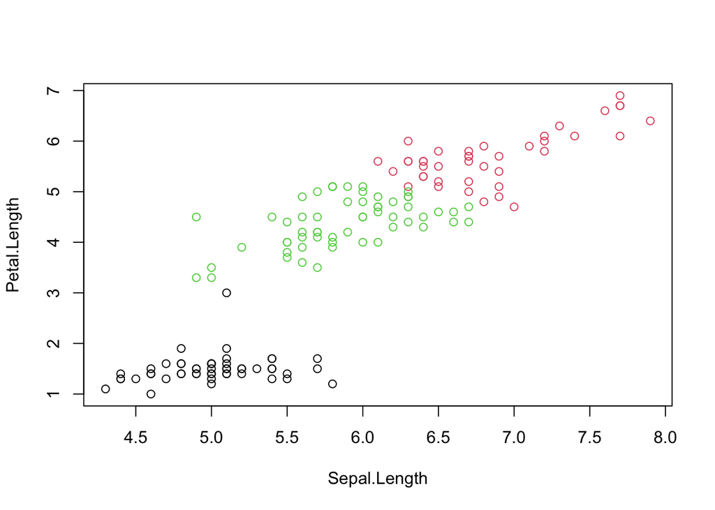

```r
i <- grep("Length", names(iris))
x <- iris[, i]
cl <- kmeans(x, 3, nstart = 10)
plot(x, col = cl$cluster)
```

```r
sample_n(x, 5)
```

```
##   Sepal.Length Petal.Length
## 1          4.8          1.4
## 2          4.7          1.6
## 3          6.0          4.5
## 4          5.2          3.9
## 5          5.0          1.6
```

```r
cl$cluster
```

```
##   [1] 1 1 1 1 1 1 1 1 1 1 1 1 1 1 1 1 1 1 1 1 1 1 1 1 1 1 1 1 1 1 1 1 1 1 1 1 1
##  [38] 1 1 1 1 1 1 1 1 1 1 1 1 1 2 3 2 3 3 3 3 3 3 3 3 3 3 3 3 3 3 3 3 3 3 3 3 3
##  [75] 3 3 2 2 3 3 3 3 3 3 3 3 3 3 3 3 3 3 3 3 3 3 3 3 1 3 2 3 2 2 2 2 3 2 2 2 2
## [112] 2 2 3 3 2 2 2 2 3 2 3 2 3 2 2 3 3 2 2 2 2 2 2 2 2 2 2 3 2 2 2 3 2 2 2 3 2
## [149] 2 3
```

```r
cl
```

```
## K-means clustering with 3 clusters of sizes 51, 41, 58
##
## Cluster means:
##   Sepal.Length Petal.Length
## 1     5.007843     1.492157
## 2     6.839024     5.678049
## 3     5.874138     4.393103
##
## Clustering vector:
##   [1] 1 1 1 1 1 1 1 1 1 1 1 1 1 1 1 1 1 1 1 1 1 1 1 1 1 1 1 1 1 1 1 1 1 1 1 1 1
##  [38] 1 1 1 1 1 1 1 1 1 1 1 1 1 2 3 2 3 3 3 3 3 3 3 3 3 3 3 3 3 3 3 3 3 3 3 3 3
##  [75] 3 3 2 2 3 3 3 3 3 3 3 3 3 3 3 3 3 3 3 3 3 3 3 3 1 3 2 3 2 2 2 2 3 2 2 2 2
## [112] 2 2 3 3 2 2 2 2 3 2 3 2 3 2 2 3 3 2 2 2 2 2 2 2 2 2 2 3 2 2 2 3 2 2 2 3 2
## [149] 2 3
##
## Within cluster sum of squares by cluster:
## [1]  9.893725 20.407805 23.508448
##  (between_SS / total_SS =  90.5 %)
##
## Available components:
##
## [1] "cluster"      "centers"      "totss"        "withinss"     "tot.withinss"
## [6] "betweenss"    "size"         "iter"         "ifault"
```

### How does k-means work

Initialisation: randomly assign class membership

```r
set.seed(12)
init <- sample(3, nrow(x), replace = TRUE)

init
```

```
##   [1] 2 2 3 3 2 1 1 2 3 2 1 2 1 2 2 2 3 1 1 3 2 3 2 1 3 2 1 1 1 2 3 2 3 2 3 1 1
##  [38] 3 1 3 3 2 3 3 1 3 1 3 2 1 3 2 1 1 1 3 2 3 1 3 3 2 2 2 2 2 1 1 3 2 3 2 1 3
##  [75] 1 2 2 3 2 2 2 3 2 2 3 2 1 3 3 1 1 3 3 2 2 1 1 3 2 1 1 3 1 1 3 2 3 3 3 1 3
## [112] 3 2 1 1 1 1 1 1 3 2 1 3 1 3 3 3 3 1 3 1 3 3 3 3 2 3 2 1 2 3 3 1 3 1 1 1 3
## [149] 1 1
```

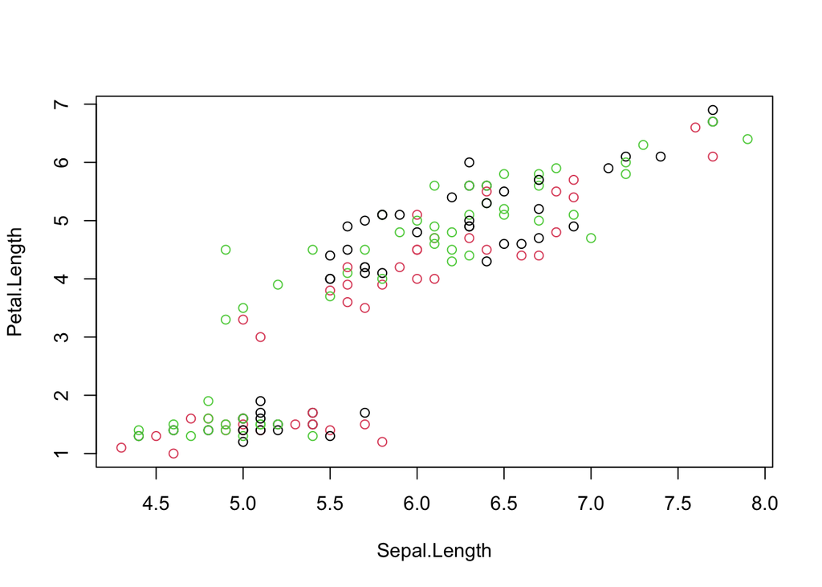

```r
plot(x, col = init)
```

Iteration:

Calculate the centre of each subgroup as the average position of all observations is that subgroup. Each observation is then assigned to the group of its nearest centre. It’s also possible to stop the algorithm after a certain number of iterations, or once the centres move less than a certain distance.

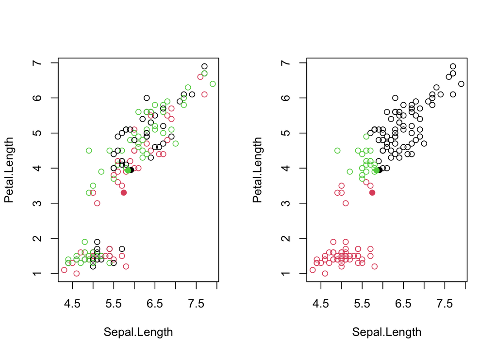

```r
par(mfrow = c(1, 2))
plot(x, col = init)

# calculate mean value of each cluster now
centres <- sapply(1:3, function(i) colMeans(x[init == i, ], ))
centres <- t(centres)
points(centres[, 1], centres[, 2], pch = 19, col = 1:3)

#calculate Euclidean distance between each row in matrix
tmp <- dist(rbind(centres, x))
tmp <- as.matrix(tmp)[, 1:3]

ki <- apply(tmp, 1, which.min)
ki <- ki[-(1:3)]

plot(x, col = ki)
points(centres[, 1], centres[, 2], pch = 19, col = 1:3)
```

Termination: Repeat iteration until no point changes its cluster membership.

```r
cl$tot.withinss
```

```
## [1] 53.80998
```

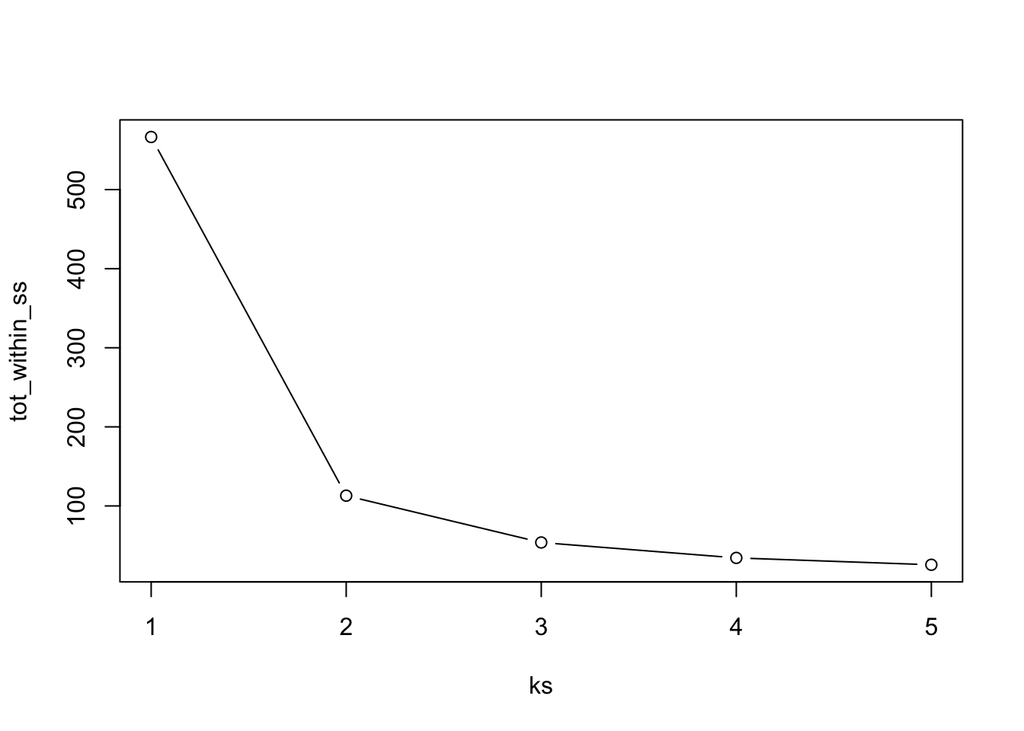

```r
ks <- 1:5
tot_within_ss <- sapply(ks, function(k) {
    cl <- kmeans(x, k, nstart = 10)
    cl$tot.withinss
})
plot(ks, tot_within_ss, type = "b")
```

## Hierarchical clustering

Initialisation: Starts by assigning each of the n points its own cluster

Iteration

Find the two nearest clusters, and join them together, leading to n-1 clusters Continue the cluster merging process until all are grouped into a single cluster Termination: All observations are grouped within a single cluster.

The results of hierarchical clustering are typically visualised along a dendrogram, where the distance between the clusters is proportional to the branch lengths.

In R:

Calculate the distance using dist, typically the Euclidean distance. Hierarchical clustering on this distance matrix using hclust

```r
d <- dist(iris[, 1:4])
hcl <- hclust(d)
hcl
```

```
##
## Call:
## hclust(d = d)
##
## Cluster method   : complete
## Distance         : euclidean
## Number of objects: 150
```

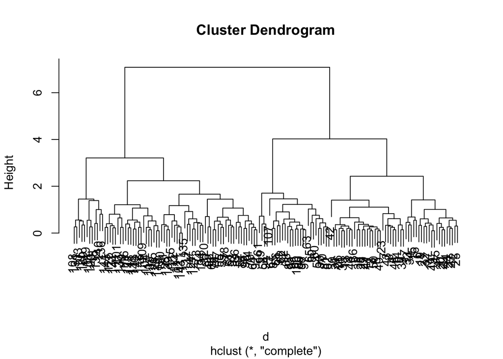

```r
plot(hcl)
```

In R we can us the cutree function to

cut the tree at a specific height: cutree(hcl, h = 1.5) cut the tree to get a certain number of clusters: cutree(hcl, k = 2)

```r
km <- kmeans(iris[, 1:4], centers = 3, nstart = 10)
hcl <- hclust(dist(iris[, 1:4]))
table(km$cluster, cutree(hcl, k = 3))
```

```
##
##      1  2  3
##   1  0 38  0
##   2  0 34 28
##   3 50  0  0
```

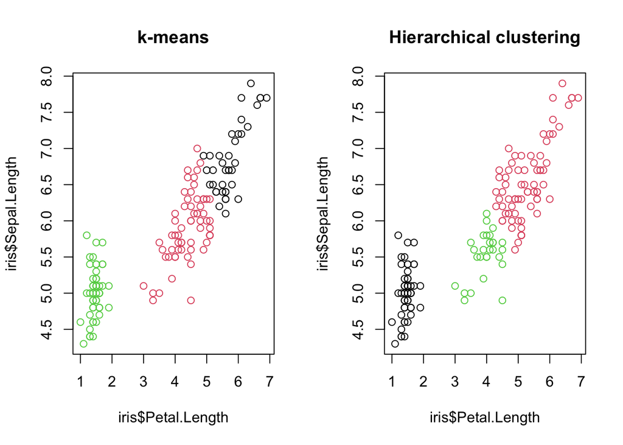

```r
par(mfrow = c(1, 2))
plot(iris$Petal.Length, iris$Sepal.Length, col = km$cluster, main = "k-means")
plot(iris$Petal.Length, iris$Sepal.Length, col = cutree(hcl, k = 3), main = "Hierarchical clustering")
```

Many of the machine learning methods that are regularly used are sensitive to difference scales.

A typical way to pre-process the data prior to learning is to scale the data, or apply principal component analysis (next section). Scaling assures that all data columns have a mean of 0 and standard deviation of 1.

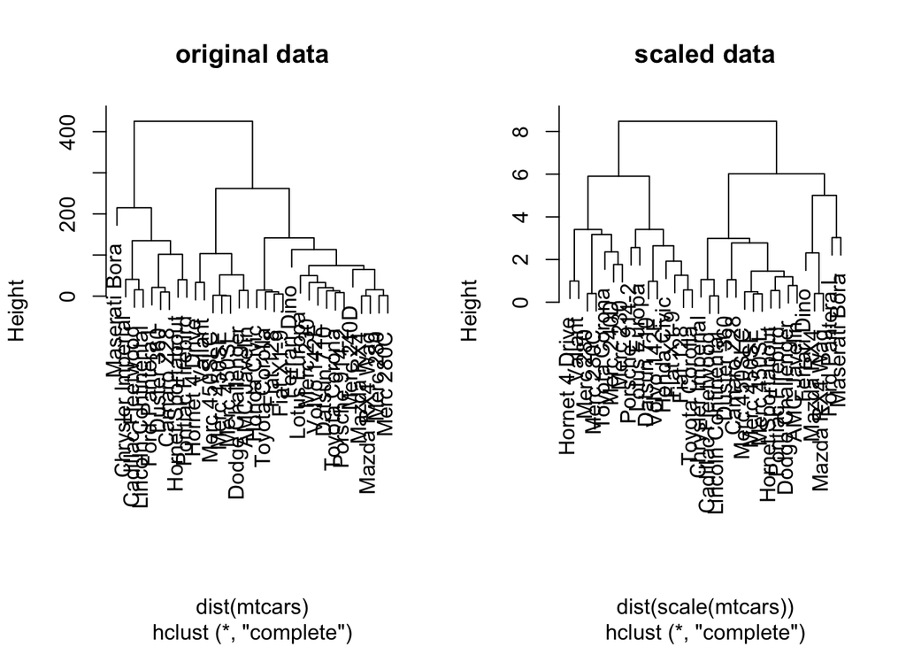

```r
hcl1 <- hclust(dist(mtcars))
hcl2 <- hclust(dist(scale(mtcars)))
par(mfrow = c(1, 2))
plot(hcl1, main = "original data")
plot(hcl2, main = "scaled data")
```

## PCA

Dimensionality reduction techniques are widely used and versatile techniques that can be used to:

find structure in features pre-processing for other ML algorithms, and aid in visualisation.

Principal Component Analysis (PCA) is a technique that transforms the original n-dimensional data into a new n-dimensional space.

Use PCA to reduce the dimension.

```r
irispca <- prcomp(iris[, -5])
summary(irispca)
```

```
## Importance of components:
##                           PC1     PC2    PC3     PC4
## Standard deviation     2.0563 0.49262 0.2797 0.15439
## Proportion of Variance 0.9246 0.05307 0.0171 0.00521
## Cumulative Proportion  0.9246 0.97769 0.9948 1.00000
```

PC1 explain 92%, PC2 explain 5%, PC3 explain 1.7%

```r
irispca
```

```
## Standard deviations (1, .., p=4):
## [1] 2.0562689 0.4926162 0.2796596 0.1543862
##
## Rotation (n x k) = (4 x 4):
##                      PC1         PC2         PC3        PC4
## Sepal.Length  0.36138659 -0.65658877  0.58202985  0.3154872
## Sepal.Width  -0.08452251 -0.73016143 -0.59791083 -0.3197231
## Petal.Length  0.85667061  0.17337266 -0.07623608 -0.4798390
## Petal.Width   0.35828920  0.07548102 -0.54583143  0.7536574
```

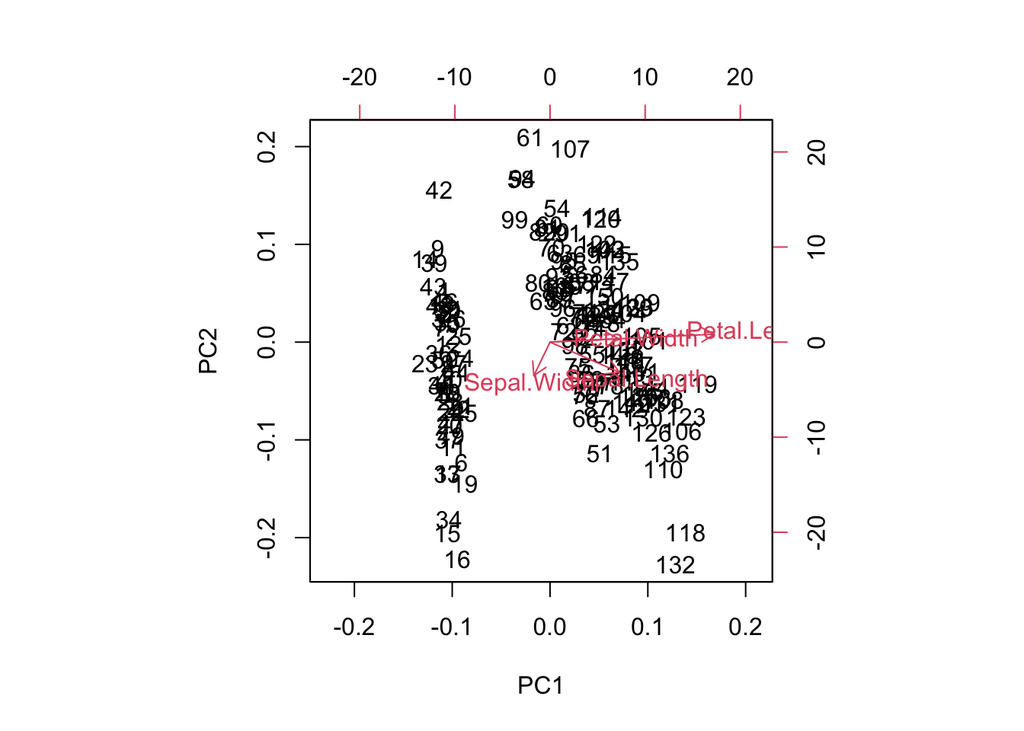

```r
biplot(irispca)
```

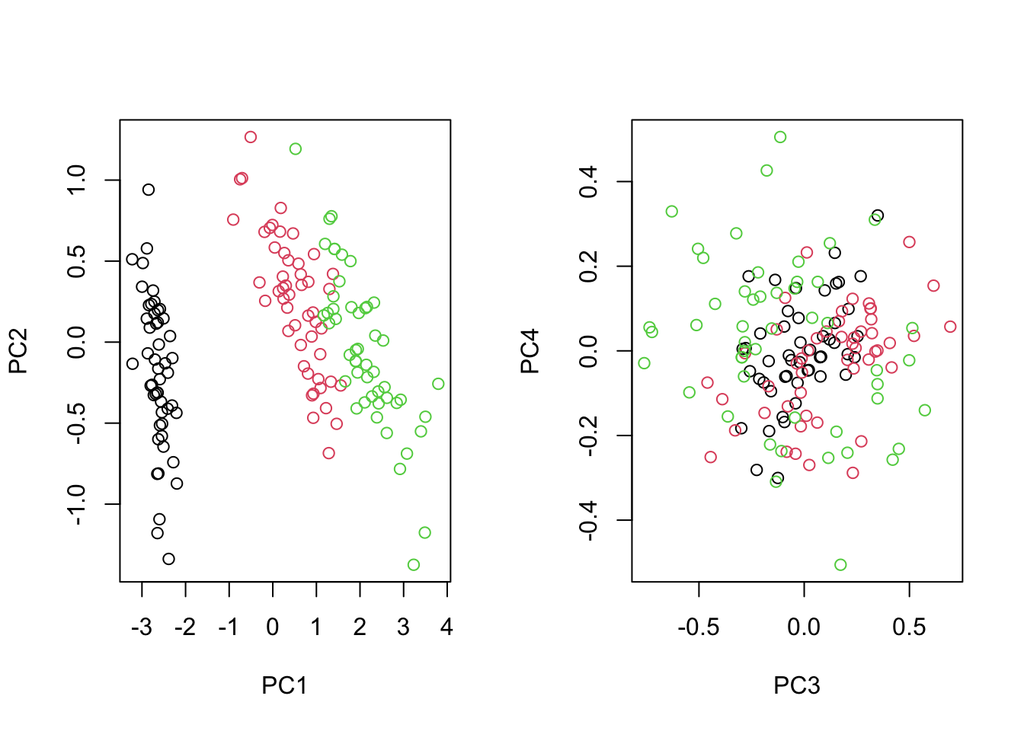

```r
par(mfrow = c(1, 2))
plot(irispca$x[, 1:2], col = iris$Species)
plot(irispca$x[, 3:4], col = iris$Species)
```

Real datasets often come with missing values. In R, these should be encoded using NA. Unfortunately, PCA cannot deal with missing values, and observations containing NA values will be dropped automatically. This is a viable solution only when the proportion of missing values is low.

## tSNE

t-Distributed Stochastic Neighbour Embedding (t-SNE) is a non-linear dimensionality reduction technique, i.e. that different regions of the data space will be subjected to different transformations. t-SNE will compress small distances, thus bringing close neighbours together, and will ignore large distances. It is particularly well suited for very high dimensional data.

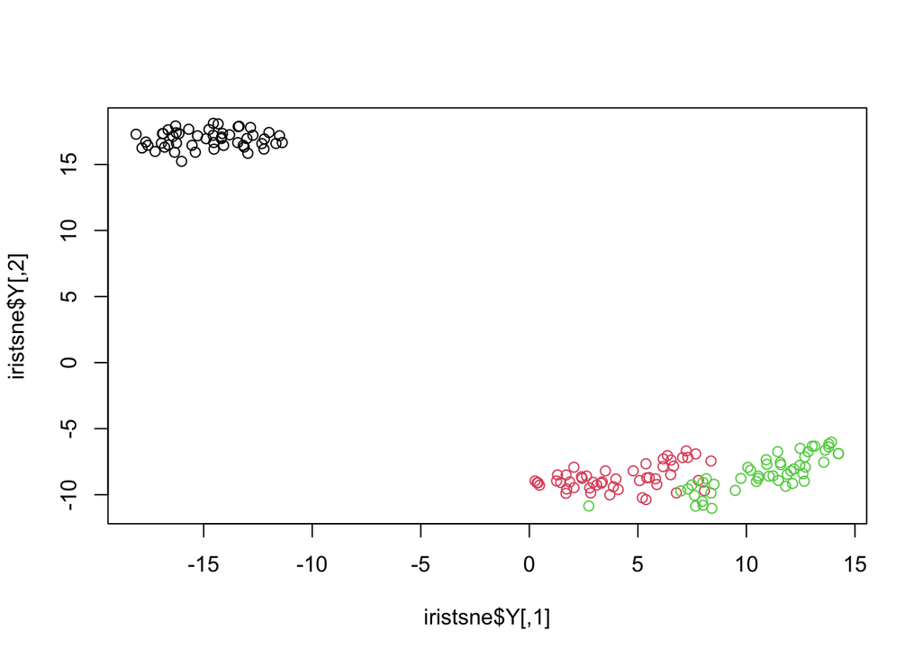

```r
library(Rtsne)
uiris <- unique(iris[, 1:5])
iristsne <- Rtsne(uiris[, 1:4])
plot(iristsne$Y, col = uiris$Species)
```

t-SNE (as well as many other methods, in particular classification algorithms) has two important parameters that can substantially influence the clustering of the data

Perplexity: balances global and local aspects of the data. Iterations: number of iterations before the clustering is stopped.